# International Political Economy

Lecture 3: Introduction to Causal Inference

2026-01-27

# Causal Inference from a Research Design Perspective

## Causal research questions

We are now empirical IPE researchers: we use data to answer questions about the world

We always start by formulating a research question (RQ).

**Our research question**

Do World Bank financing projects increase human development?

The RQ can be derived from theory or from a “real-world” puzzle

The RQs we care about are often (but not always) **causal**: we ask *if* WB projects **cause** development and if so, *how much*

But what does it mean for a question to be causal? How do we proceed with our empirical study if we want to answer a causal question?

## Causality and counterfactuals

Causal inference is the process of determining causal effects

The key notion in causal inference is counterfactual: what would have happened to a unit in an alternative state of the world where the “cause” we want to study did not happen

- What would have happened to districts **with** WB projects had the project **not** been implemented?
- What would have happened to districts **without** WB projects **had** the project been implemented?

## Causal effects

Consider our district under two different counterfactual conditions:

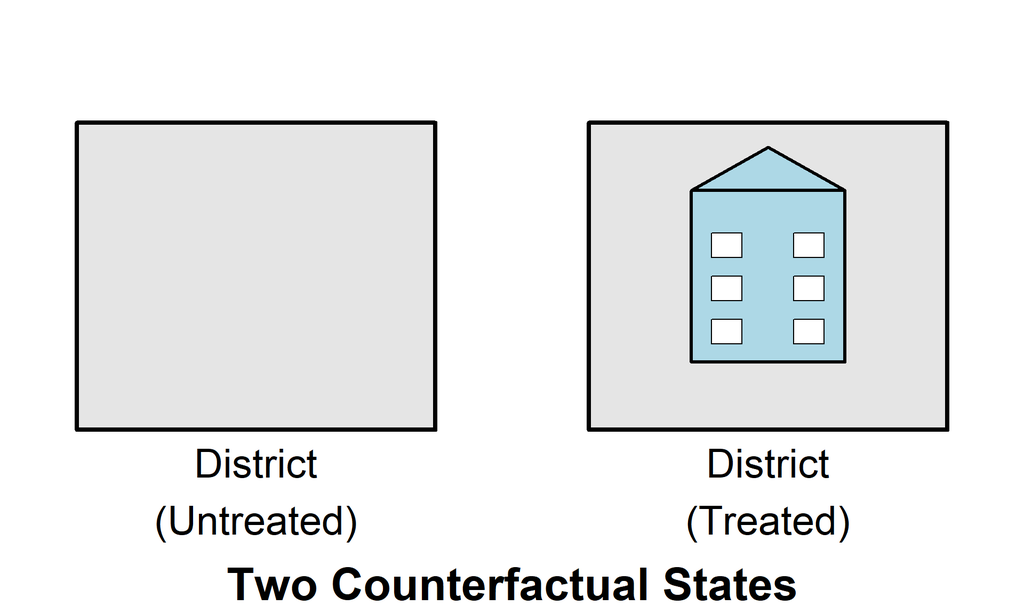

- WB project $\implies$ treated
- no WB project $\implies$ untreated

The only difference between the two conditions is the treatment (project implemented or not), everything else remains unchanged

## Causal effects

Consider our district under two different counterfactual conditions:

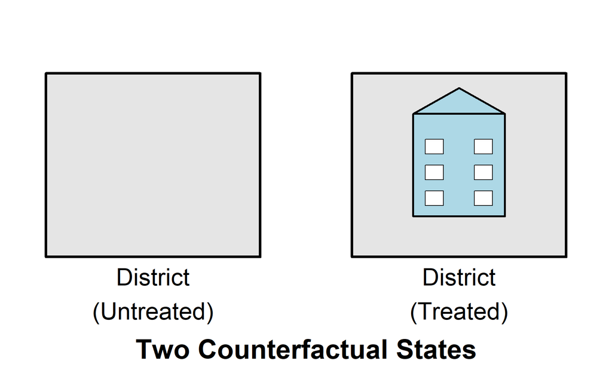

Call $y$ the outcome variable (e.g., health, life expectancy)

The **unit causal effect** (or treatment effect) of the project is the difference in $y$ of the district (unit) between the two conditions

The **average causal effect** (or treatment effect) of the project is the average of the unit treatment effects for all units (all districts)

What is the problem here?

## Causality and counterfactuals

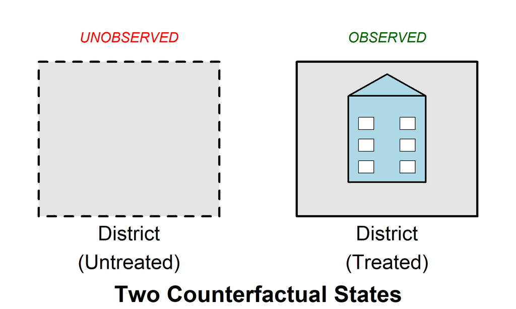

The problem is that either the project (the treatment) was implemented or it wasn’t. A district (unit) cannot be treated and untreated at the same time. This is the fundamental problem of causal inference

**The fundamental problem of causal inference**

We cannot observe the same unit under two conditions, so the causal effect for a single unit cannot be observed

We also say that the effect for a single unit cannot be identified from the data

What do we do, then?

## Average treatment effects

Suppose projects (treatment) are allocated **randomly** to districts (units)

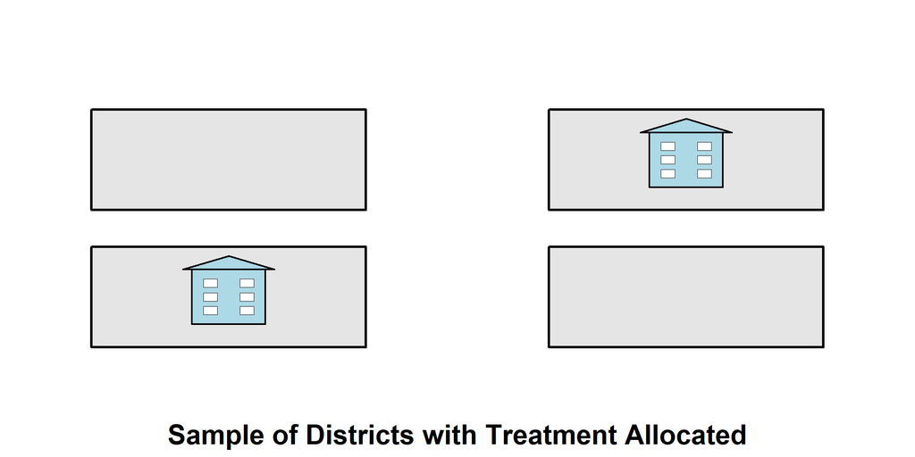

- Districts with WB project $\implies$ treatment group
- Districts without WB project $\implies$ control group

With this *random assignment*, we can identify the **average causal effect** of projects in the sample (i.e., the average of unit causal effects)

Key intuition: random assignment is “blind” to any differences between units. *On average*, the control group is very similar to the treated group if it were not treated

- Example 1: height
- Example 2: drug in hospital

In causal inference, we mostly focus on the **ATE** (average treatment effect).

In papers, people sometimes refer to the ATT or the LATE. For this class, just know that they refer to averages of causal effects in the sample of units (note).

## Estimate an effect under random assignment

If the WB randomizes projects across districts, we can simply compare the average $y$ between the treated and control group.

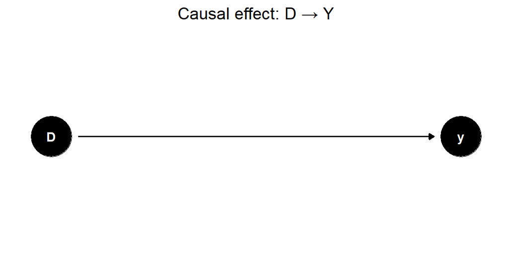

We can do this with a *linear regression*.

$y = \alpha + \beta D + \varepsilon$

- $y$ is the development outcome
- $D$ is the variable that indicates whether a project was implemented (1 if yes, 0 if no)
- $\beta$ is the ATE

## Problems of causal inference when we move outside of experiments

If we want to estimate the effect of a factor $x$ on an outcome $y$ we need a sample of units where $x$ is assigned randomly. The average causal effect of $x$ is the difference in $y$ between the two groups.

But how likely is it that something is randomly assigned in the real world?

Researchers (doctors and social scientsts) conduct **randomized experiments** to estimate causal effects with certainty

But we social scientists are interested in causal effects (e.g., civil war violence $\rightarrow$ political participation; trade flows $\rightarrow$ growth) where randomization is obviously unfeasible and/or unethical

In these cases, we can only use events and data that have already happened in the world

To do causal inference, we need assumptions (called identification assumptions) about how “randomly” the “treatment” is assigned

We can do causal inference only if our assumptions are realistic (i.e., very likely to be satisfied)

This depends on our *knowledge* of the assignment process in the real world

## Estimate an effect under endogeneity

Imagine that the WB decides where to start a project based on local poverty conditions: districts with lower income have a higher probability of being assigned a project.

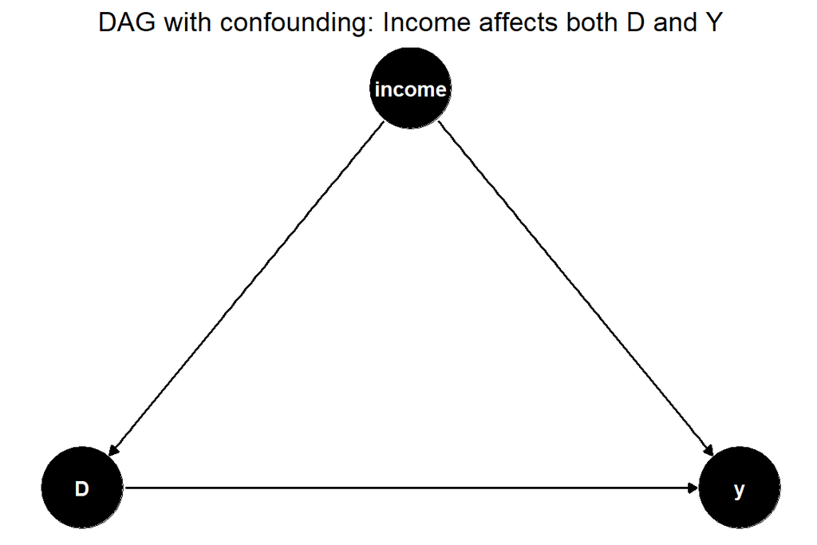

If we simply compare treated and non-treated districts as before, and run $y=\alpha + \beta D + \varepsilon$, our $\beta$ will be
$$\beta= \underbrace{\text{ATE}}_{\text{causal effect}} + \underbrace{\text{pre-existing income differences}}_{\text{bias}}$$

We call this a problem of *selection* or *endogeneity* or *confounding* or *omitted variable*.

- Intuition 1: if two things change at the same time, we are not sure which one was the cause
- Intuition 2: this is what we mean when we say that correlation is not causation

## Estimate an effect under endogeneity

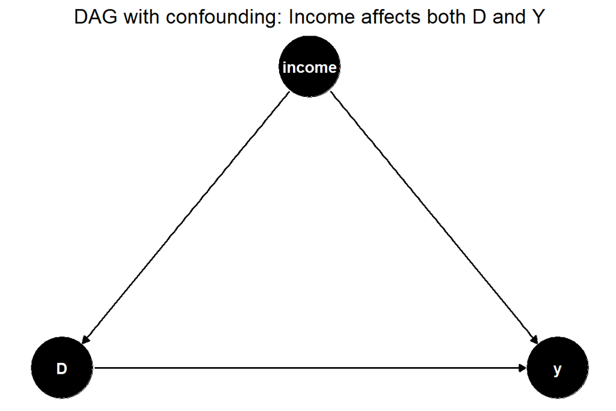

To remove the bias, we can include the income variable in the regression: in this way we “keep it constant” and compare units with the same value of income

$y = \alpha + \beta D + \gamma \text{Income} + \varepsilon$

and now

$\beta=\text{ATE}$

## Common forms of endogeneity

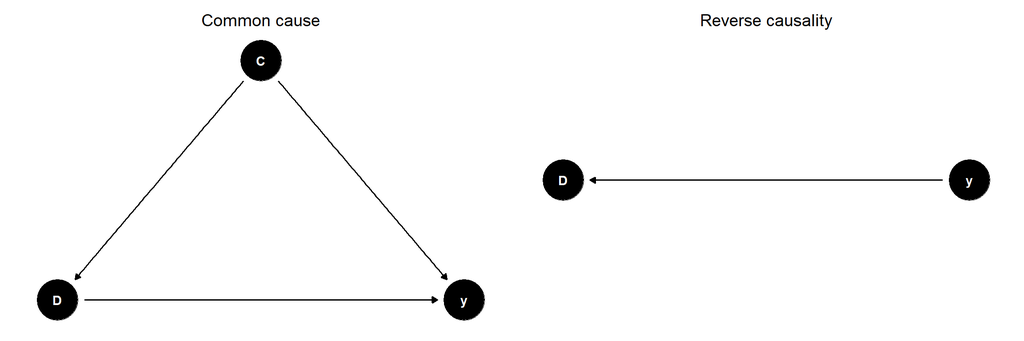

- Common cause: some other variable is causing both the treatment and the outcome
  - Example?
- Reverse causality: the outcome causes the treatment and not vice-versa
  - Example?

## Causal research design

In this example, we imagined we knew the source of endogeneity or confounding: income. Therefore, when we compare units with the same income level, treatment is random between them

If we planned this study before collecting the data, our research design would be based on this assumption and we would plan to run a linear regression controlling for income to cleanly estimate the ATE

Now, in your mind, replace “WB projects” with “civil war” or “trade flows”. You immediately see how complex the assignment process is for real-world “treatments” and how likely endogeneity is

To make causal claims on these topics we have to design our analyses thinking carefully about the assignment process in the real world to overcome endogeneity

We can look for details of the actual assignment process to “find” the appropriate counterfactuals in the data

# Common Research Designs in IPE

## Randomized experiments

The “gold standard” of causal inference. Treatment assignment (and identification) is controlled by the researcher

Less common in IPE than in other fields (because IPE is mostly concerned with things that “cross borders”)

- Field experiments. Treatment administration and outcome measurement happen in the real world.
  - Most common in medical research
  - Commonly used in American Politics, Comparative Politics, Development Economics
- Survey experiments. Treatment administration and outcome measurement happen within a survey.
  - Longer tradition in political science to study public opinion
  - Used to understand how information or communication affects voters’ attitudes or opinions
  - Measures psychological mechanisms rather than real-world effects
- Lab experiments. Treatment administration and outcome measurement happen in an artificial lab setting.
  - Stronger tradition in economics
  - Used to understand decision-making in strategic interactions

## Natural experiments

Circumstances in the real world where something “happens by chance”

Such circumstances exist, especially in nature (e.g., earthquakes). In the human world they are hardly credible without further qualifications

The question to ask is always: who “decides” the treatment? What do they know? What are their goals?

The answer to this question reveals plausible research designs

## Selection on observables

If we believe that the “endogeneity” of treatment is due to known, observed variables, we can collect them and “control” for them

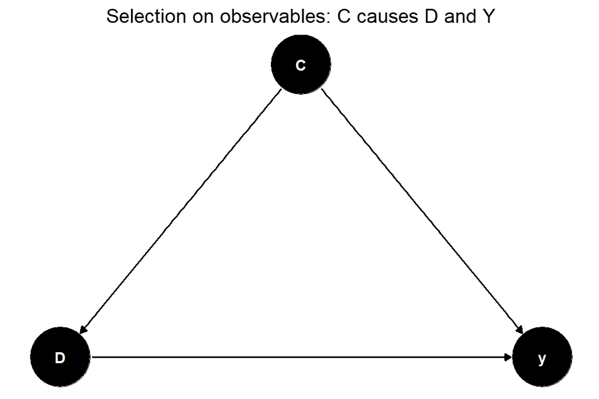

This is analogous to running little experiments between units with the same values of the confounding variables, and taking the average of the effects from these experiments.

Different ways to do it:

**Linear regression**. The confounding variables are included in the regression as independent variables.

$y = \alpha + \beta D + \gamma \text{(control variables)} + \varepsilon$

**Matching**. Other techniques to compare “more similar” units, following a similar logic to “controlling”. We will not go into the details in this class. If you find them, just know that they are similar to controlling.

## Instrumental variables

If we believe that the “endogeneity” of treatment is due to unobserved variables, control is insufficient (we lack the control variables). An instrumental variable can solve this problem

An instrumental variable (or just an instrument) is a variable that is exogenous/random and has a causal effect on the treatment variable. Conceptually, it is a random “push” to accept the treatment

Under some assumptions, we can estimate an average causal effect by “instrumenting” the endogenous treatment with the exogenous instrumental variable

## Instrumental variables

If we believe that the “endogeneity” of treatment is due to unobserved variables, control is insufficient (we lack the control variables). An instrumental variable can solve this problem

$$\underbrace{D}_{\text{endogenous treatment}} = \delta + \theta \underbrace{Z}_{\text{instrument}} + \phi X + u \quad \text{(First stage)}$$

$$y = \alpha + \beta \underbrace{D}_{\text{endogenous treatment}} + \gamma X + \varepsilon \quad \text{(Second stage)}$$

The statistical model estimates the first equation (first stage), then predicts the values of $D$ and replaces the observed values of $D$ in the second equation (second stage) with the predicted values.

This is equivalent to controlling for the “endogenous part” of the treatment $D$ and using only the “exogenous part” of the treatment to estimate the ATE.

## Instrumental variables

Examples of IV designs

- Example 1
- Example 2
- Example 3
- Example 4

| Research Question | Treatment | Instrument | Outcome |
| --- | --- | --- | --- |
| Does social pressure increase turnout? | Reading an appeal to vote | Randomized postcard with an appeal | Individual turnout |

| Research Question | Treatment | Instrument | Outcome |
| --- | --- | --- | --- |
| Does education improve earnings? | Years of schooling | Quarter of birth | Annual income |

| Research Question | Treatment | Instrument | Outcome |
| --- | --- | --- | --- |
| Do trade policies affect growth? | Free trade agreement | Geographic proximity | GDP per capita |

| Research Question | Treatment | Instrument | Outcome |
| --- | --- | --- | --- |
| Does economic growth reduce civil conflict? | GDP per capita growth | Rainfall variation | Civil conflict incidence |

## Instrumental variables

IV design requires assumptions. The ones that are relevant for us at this stage are:

- The instrument is random (or random after controlling for covariates)
- The instrument has an effect on the treatment
- The instrument has an effect on the outcome only through the treatment. This is called the Exclusion restriction

There are other assumptions which are more technical, we will not go through them. You find the discussion in Keele’s reading for today.

## Other research designs: DID and RDD

Read this slide if you are interested. We will go through these other methods later in the course if needed.

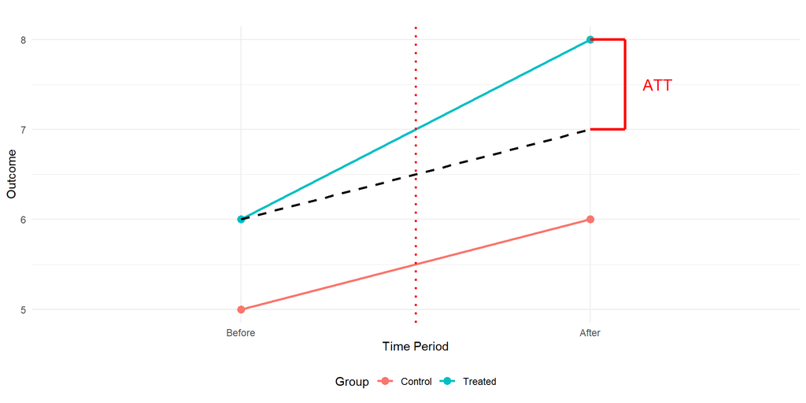

Difference-in-Differences

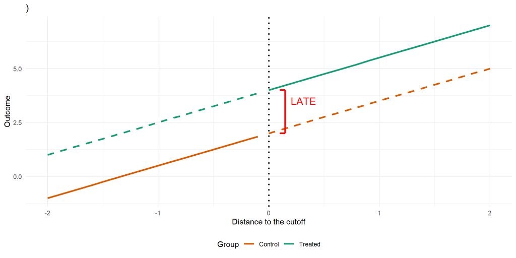

Regression Discontinuity

**Difference-in-Differences**

- The treated group is treated at some point in time
- We observe the treated and control group before and after the treated group receives the treatment
- For each group, we subtract the outcome after treatment to the outcome before treatment (first difference). The we subtract the first difference of the control group from the first difference of the treated group (diff-in-diff)

**Regression Discontinuity**

- Treatment is given according to the value of some variable
- Only units with a value above/below a given cutoff point receive treatment
- We compare only units very close to the cutoff point to approximate a randomized experiment

## Next

- Review of this class
- Discussion of IV assumptions
- Discussion of a Nobel-prize winning article: Acemoglu, Johnson, and Robinson (2001)